# Politologie (júlový turnus)

Zpět na rozcestník zpětné vazby | Tento report we Wordu | Data v CSV

## Hodnocení kurzu

Průměrná známka:

| Blok setkání | Průměrná známka |
| --- | --- |
| A | 2.20 |
| B | 1.65 |
| oba | 1.92 |

### Hodnocení po dnech

A a B jsou bloky (A je 9-10:30, B je 11-12:30)

Známky jsou jako ve škole: 1 je nejlepší, 5 nejhorší

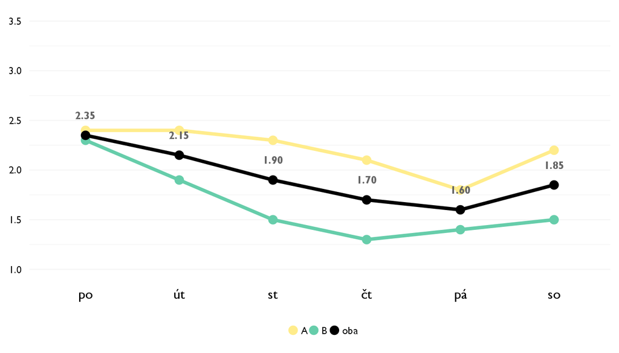

### Co se na kurzu líbilo

- Vysvětlení co dělá politolog
- Diskusie preotze som sa VELMI vela dozvedela
- Konečně jsem si vyjasnil některé pojmy a termíny, především na ose levice/pravice, konzervativec/liberál a jejich vzájemný vztah. Na hodinách politologie nebyly ani náznaky frontální výuky, smekám.
- skupinove cvicenia
- Hlbšie poznávať jednu z mojích obľubených tém, s ktorou sa dennodenne stretávame.
- Nejvíce se mi líbilo rozdělení vládních systémů podle státu. Přišlo mi to velmi zajímavé a přínosné.
- Systémy vlád ve VB a USA. Nevěděla jsem o tom mnoho a bylo to velmi zajímavé.
- Najviac sa mi páčilo Petrove prezentovanie o danej téme/ vysvetľovanie
- To ze sme mali priestor sami oveciach premyslat
- Diskuse.
- podrobny popis politickych systemov, prieskumy
- Byl jsem rád, že nám Petr ujasnil, jak funguje EU a jaké všechny instituce do ní patří, také se mi líbily počáteční teoretické hodiny o tom, co vlastně jsou politika a demokracie. Nevadila mi vlastně ani poměrně dlouhá četba, naopak mě inspirovala a dostal jsem nové podněty, co bych si jednou chtěl přečíst, jelikož se (zejména díky Petrovi) nejspíš chci politologii do budoucna věnovat.
- Témy ktoré sme preberali, texty a nase dkiakusie
- Niektore bloky ktore obsahovali zaujmave info
- Politologické štúdie a zaujímavé vysvetlenie základnych pincípov demokracie (teoretické aj praktické).
- Líbilo s mne diskutování o nejruznejších tématech a také interaktivní metody výuky. Také lektor byl velmi sympatický.
- Nové poznatky ohľadom politiky, ktoré možem využiť v debate.
- Iné pohľady na vec, pohľad od odborníka
- Dobré vysvetlenie fungovania politiky
- Diskusia o EU a rôzne prepojenia voličov a zakonodárnej moci.

### Co na kurzu změnit

- Méně času na cvičení by kurzu dodalo větší švih
- Prvu hodinu vymysliet trosku putavejsie
- Část věcí pro mě nebyla nová- ocenil bych, kdyby se spíše otevřely otázky jako výhody konzervatismu a liberalismu pro systém… Učit se jak systém funguje je de facto opakování hodin ZSV. Otevírat poslední den téma fungování EU mi přišlo nadbytečné a ne dostatečně do hloubky.
- viac diskusii ucit sa ine veci ako v skkole na obcianskej nauke
- Miestami mi chýbalo trochu viac praxe a diskusii. Možno by som vypustil prvé dve hodiny kurzu alebo by som ich spojil do jednej, keďže išlo o všeobecne známejšie témy.
- Nejdříve by se měla daná látka probrat a až poté by se měly dělat aktivity na dané téma.
- Dost náročné.
- Bolo tam príliš veľa opakovania z predchádzajúcej hodiny a diskusie, a preto sme potom nestíhali výklad alebo podobne. Pridala by som viac výkladu a následne diskusiu, pretože nemám pocit, že by som sa toho nejako veľa dozvedela.
- Mne sa velmi tento kurz nepacil. Bol dost nudny a miestami sme prechadzali cez veci strasne plytko. 20 minutove opakovanie z minulej hodiny nepomaha, len zbytocne ubera cas
- Méně čtení.
- pridat viac teorie a vysvetlovania
- Za sebe bych ocenil, kdybychom se méně věnovali např. politickému systému a rozdělení moci v Čechách a na Slovensku, jelikož jsem si myslel, že jde o věci, o kterých má přehled téměř každý. Jak se však ukázalo, většina členů kurzu neměla o jeho fungování ani tušení, takže chápu Petra, že jsme téma museli probírat tak dlouho. Mně však mnoho nového nepřineslo a nestihli jsme kvůli tomu jiné věci, které by mě možná zajímaly o trochu víc.
- Spravit ho zaujmavejsi, nenechat ho vacsinou na urovni “basic and not interesting” info, nechat viac priestoru na diskusie k zaujmavim otazkam ( nie k basic info)
- Neviem do akej miery je to možné, ale ja by som rada skúšala prísť na niektoré veci práve pomocou rôznych štúdii.
- Nic, byl super.
- Viac interaktívne a svižnejšie. Občas ma to nudilo a zaspával som.
- Trošku viac akčnejšie, viac otvárať diskusie, zaujať viac účastníkov
- Menej povinného textu alebo o trochu menej zložitejších textov
- Chcel by som vidieť trošku viac teorie ako diskusie.

## Hodnocení lektora

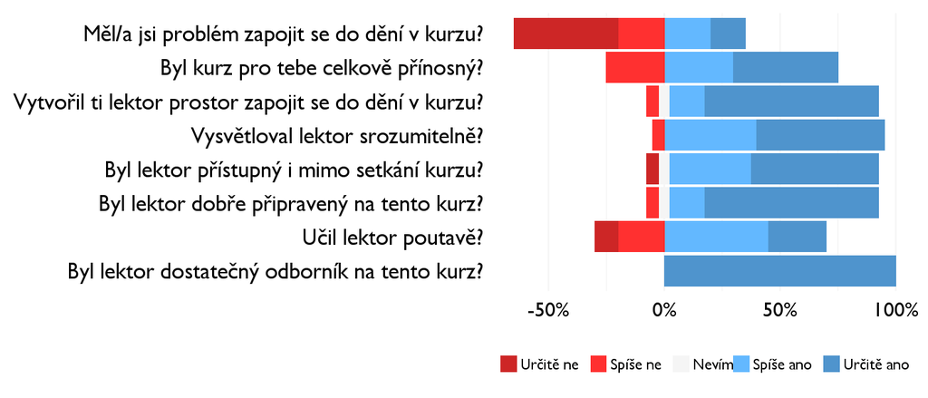

### Komentáře k lektorovi

- viac nas zapajat by bolo lepsie neposlat tolko vela materialov
- Ocenila bych více přednášek, protože jsme většinou museli na věci přicházet sami, což mi moc nevyhovovalo, jelikož jsme o dané problematice většinou nic moc nevěděli…
- Viac výkladu
- Bol nudny a dal nam nehorazne vela citat. Potom sme s tym vsak az tak nerobili. Takisto to bolo take spomalene.
- Žádný problém, těžko na politologii hledat lepšího člověka, než je právě Petr.
- Lektor skor na vysoku skolu, velmi akademicke vedenie hodiny

## Náročnost kurzu

### **Jak hodnotíš náročnost…**

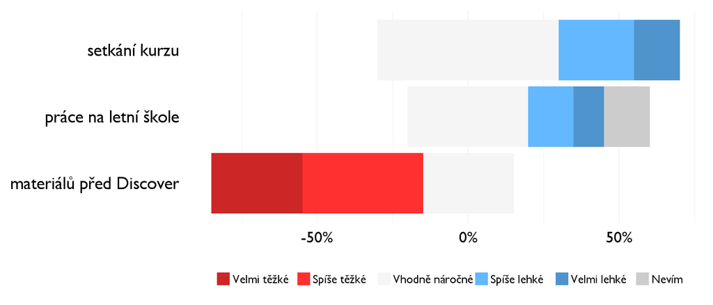

## Didaktika

Na některé otázky jsme se na augustovém turnuse neptali - tam uvidíte nadpis bez grafu.

### Jak lektor učí a měl by to změnit?

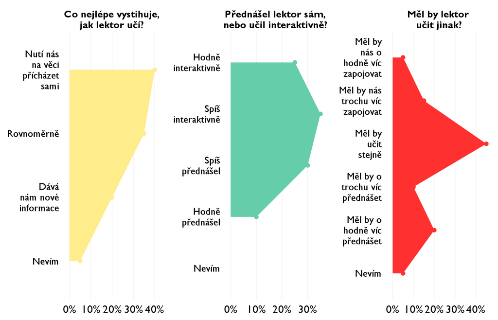

### Jak se studentům nejlépe učí?

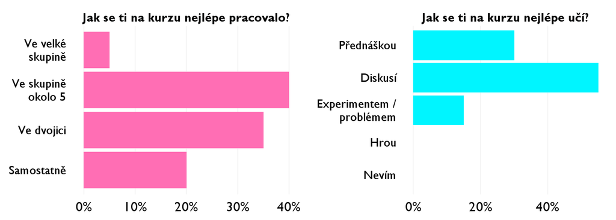

## Ovlivnil tě kurz nějak?

**Pokud ano, jak? Pokud ne, proč ne?**

- V budoucím studiu
- Ano, pretoze mam ovela vecsie poriadok v politickej scene, ale co sa tyka buducnosti asi ani nie.
- Pochopil jsem (alespoň částečně) politický systém ČR a osu levice/pravice. Konečně! :)
- dozvedela som sa aj nove veci, a zistila som, ze ajked je politologia zaujimava, tak ju asi nepojdem studovat
- Ukázal mi, že až tak nerozumiem tomu o čom som si myslel, že sa v tom vyznám a pomohol mi zorientovař sa v tom.
- Díky kurzu jsem se více dozvěděla o tom, jak to v politice funguje a uvědomila jsem si, že bych to v budoucnu jako zaměstnání dělat nemohla, což beru rozhodně zapřínosné. :-)
- Jsem ráda, že jsem si kurz politologie vybrala, protože jsem si díky němu rozšířila obzory, ale zároveň jsem zjistila, že se jí v budoucnu nechci věnovat.
- zistila som, že politológia ma baví, ale nechcela by som ju študovať.
- Zistila som ze politologia nie je pre mna. Urcite som sa aj nieco naucila ale nebolo to zaujimave
- Zvýšil můj zájem o danou oblast.
- naucil ma ako funguje politika v zakulis
- Utvrdil mě v tom, že bych politologii rád studoval, takže určitě ano.
- Rozmylsam o studia politologie na univerzite.
- hej, prisiel som na to ze politologia nieje uplne to co som si myslel a viem ze sa jej az tak nechcem venovat
- Určite, utriedila som si veci, ktoré rozhodne zužitkujem či už pri voľbách, alebo počas voľného času, keďže ma to dosť zaujíma.
- V pohledu na politické strany, demokracii a EU.
- Nie.
- Vidím viac do témy
- Dal mi nový pohľad na fungovanie spoločnosti a na to prečo je to tak ako to je
- Ano ovlivnil. Dozvedel som sa veľa zaujimvostí a zlepšil všeobecný prehľad.